# PEC 2 Machine Learning

Predicción de interacción entre péptido y el complejo mayor de histocompatibilidad tipo I con Artificial Neural Networks (ANN) y Support Vector Machines (SVM)

María Plaza García

15 de May, 2020

# Introducción

En esta PEC vamos a resolver un análisis relacionado con la modelización de la interacción entre el complejo mayor de histocompatibilidad tipo I (MHCI, en inglés) y péptidos.

En la inmunoterapia contra el cancer las células T deben activarse al exponerse a péptidos tumorales unidos a MHCI (pMHCI). Al analizar la genética del tumor, se pueden identificar péptidos relevantes y, dependiendo del tipo particular de MHCI que tiene el paciente, podemos predecir qué interacción péptido MHCI (pMHCI) es probable que esté presente en el tumor del paciente y, por lo tanto, qué pMHCI se deben usar para activar las células T.

Los ficheros necesarios para realizar la PEC estan en formato csv con separador punto y coma. En cada registro del fichero peptidos.csv se tienen dos variables: 1) el péptido, 2) la clase de interacción donde NB significa no interacción y SB significa si interacción.

La manera elegida para representar los datos es un paso crucial en los algoritmos de clasificación. En el caso que nos ocupa, análisis basados en secuencias, se usará la transformación denominada one-hot encoding. El one-hot encoding representa cada aminoácido por un vector de 20 componentes, con 19 de ellas a 0 y una a 1 indicando el aminoacido. Pongamos por ejemplo, el aminoácido A se representa por (1,0,. . . ,0) y el aminoácido R por (0,1,0, . . . , 0). Por tanto, para una secuencia de 9 aminoácidos, como en nuestro caso, se obtendrá un vector de 20*9 componentes, resultado de concatenar los vectores para cada uno de los 9 aminoácidos.

# Algoritmo Red Neuronal Artificial

Una red neuronal, según Freman y Skapura, es un sistema de procesadores paralelos conectados entre sí en forma de grafo dirigido. Esquemáticamente cada elemento de procesamiento (neuronas) de la red se representa como un nodo, que recibe y envia señales (información). Se crea entonces una red con diferentes capas interconectadas para procesar la información. Cada capa esta formada por un grupo de nodos que transmite la información a los otros nodos de las capas siguientes. Estas conexiones establecen una estructura jerárquica que tratando de emular la fisiología del cerebro busca nuevos modelos de procesamiento para solucionar problemas concretos del mundo real. Lo importante en el desarrollo de la técnica de las RNA es su útil comportamiento al aprender, reconocer y aplicar relaciones entre objetos y tramas de objetos propios del mundo real. Es por tanto, una nueva forma de computación o modelo matemático inspirado en modelos biológicos y compuesto por un gran número de elementos procesales organizados en niveles.

Debido a que presentan un gran número de características similares a las del cerebro humano, las redes neuronales son capaces de aprender de la experiencia, de abstraer características esenciales a partir de entradas que presentan información irrelevante, de generalizar de casos anteriores a nuevos casos…etc. Todo esto permite su aplicación en un gran número de areas muy diferenciadas:

- Aproximación de funciones, o el análisis de regresión, incluyendo la predicción de series temporales, funciónes de aptitud y el modelado.
- Clasificación, incluyendo el reconocimiento de patrones y la secuencia de reconocimiento, detección y de la toma de decisiones secuenciales (diagnostico m’edico, aplicaciones financieras, sistemas radar, reconocimiento facial, clasificación de señales, control del vehículo, predicción de trayectorias, el control de procesos, manejo de recursos naturales, juegos y la toma de decisiones como el backgammon, ajedrez, póquer…)
- Procesamiento de datos, incluyendo el filtrado, el agrupamiento, la separación ciega de las señales y compresión (diferenciando entre informes deseados y no deseados en redes sociales y prevención de spam)
- Robótica, incluyendo la dirección de manipuladores y prótesis.
- Ingeniería de control, incluyendo control numérico por computadora.

Las fortalezas y debilidades de este algoritmo son:

[output not shown]

# Algoritmo Support Vector Machine

El método de clasificación-regresión Máquinas de Vector Soporte (Vector Support Machines, SVMs) es un algoritmo de aprendizaje supervisado que fue desarrollado en la década de los 90 dentro de campo de la ciencia computacional. Si bien originariamente se desarrolló como un método de clasificación binaria, su aplicación se ha extendido a problemas de clasificación múltiple y regresión. SVMs ha resultado ser uno de los mejores clasificadores para un amplio abanico de situaciones, por lo que se considera uno de los referentes dentro del ámbito de aprendizaje estadístico y machine learning.

Las máquinas de vectores de soporte pertenecen a una clase de algoritmos de aprendizaje automático llamados métodos de kernel y también se conocen como máquinas de kernel. Se fundamentan en el Maximal Margin Classifier, que a su vez, se basa en el concepto de hiperplano óptimo como una superficie de decisión de tal manera que se maximiza el margen de separación entre las dos clases en los datos. Los vectores de soporte se refieren a un pequeño subconjunto de las observaciones de entrenamiento que se utilizan como soporte para la ubicación óptima de la superficie de decisión.

Cuando los datos no son separables de forma lineal, es necesario el uso de kernels, o funciones de similitud y especificar un parámetro determinado para minimizar la función de coste. La elección de este parámetro es en base ensayo/error, pero se buscan valores que no sean extremos en la búsqueda del equilibrio sesgo/varianza. Los kernels más populares son el lineal y el gausiano, aunque hay otros como el polinomial, string kernel o chi-square kernel.

En R, las librerías e1071 y LiblineaR contienen los algoritmos necesarios para obtener modelos de clasificación simple, múltiple y regresión, basados en Support Vector Machines.

Algunos casos de éxito de las máquinas de vectores de soporte son:

- reconocimiento óptico de caracteres
- detección de caras para que las cámaras digitales enfoquen correctamente
- filtros de spam para correo electrónico
- clasificar genes diferencialmente expresados a partir de datos de microarrays
- reconocimiento de imágenes a bordo de satélites (saber qué partes de una imagen tienen nubes, tierra, agua, hielo, etc.)
- procesamiento de lenguaje natural, reconocimiento de voz e imagen y visión por computadora
- clasificación de texto en distintas categorías temáticas
- detección de eventos críticos de escasa frecuencia, como terremotos

La capacitación para una SVM tiene dos fases:

1. Transformar los predictores (datos de entrada) a un espacio de características de alta dimensión.
2. Resuelver un problema de optimización cuadrática para ajustar un hiperplano óptimo y clasificar las características transformadas en dos clases. El número de características transformadas está determinado por el número de vectores de soporte. Solo los vectores de soporte elegidos de los datos de entrenamiento son necesarios para construir la superficie de decisión. Una vez entrenado, el resto de los datos de entrenamiento son irrelevantes.

Las fortalezas y debilidades de este algoritmo son:

| **Fortalezas** | **Debilidades** |
| --- | --- |
| - Uso en predicción y clasificación. Uso bastante extendido | - Requiere especificar parámetro C y función de kernel (prueba y error) |
| - Funciona de forma óptima con ruido | - Lento de entrenar, sobre todo a medida que aumenta el número de características |
| - Facilidad de uso en comparación de las redes neuronales | -Al igual que las redes neuronales es difícil de interpretar el funcionamiento interno. |
| - Eficaz en espacios de grandes dimensiones | - No proporcionan directamente estimaciones de probabilidad, éstas se calculan utilizando una validación cruzada quíntuple. |
| - Todavía eficaz en casos donde el número de dimensiones es mayor que el número de muestras | - Complejidad temporal del algoritmo |
| - Utiliza un subconjunto de puntos de entrenamiento en la función de decisión (llamada vectores de soporte), por lo que también es eficiente en memoria |  |
| - Versátil: se pueden especificar diferentes funciones del núcleo para la función de decisión. |  |

# Trabajando con los datos “peptidos”

## Descripción y analisis preliminar de los datos

Un logotipo de secuencia consiste en una pila de letras en cada posición. Los tamaños relativos de las letras indican su frecuencia en las secuencias. La altura total de las letras representa el contenido de la información de la posición, en bits.

```r
library(ggseqlogo)

# dataset <- read.csv(file=file.path(params$folder.data,params$file1))
# length(complete.cases(dataset))

library(readr)
peptidos <- read_delim("dataset/peptidos.csv",
    ";", escape_double = FALSE, trim_ws = TRUE)
length(complete.cases(peptidos))
```

```
[1] 15840
```

```r
str(peptidos)
```

```
tibble [15,840 x 2] (S3: spec_tbl_df/tbl_df/tbl/data.frame)
 $ sequence: chr [1:15840] "LMAFYLYEV" "HQRLAPTMP" "FMNGHTHIA" "WLLIFHHCP" ...
 $ label   : chr [1:15840] "SB" "NB" "SB" "NB" ...
 - attr(*, "spec")=
  .. cols(
  ..   sequence = col_character(),
  ..   label = col_character()
  .. )
```

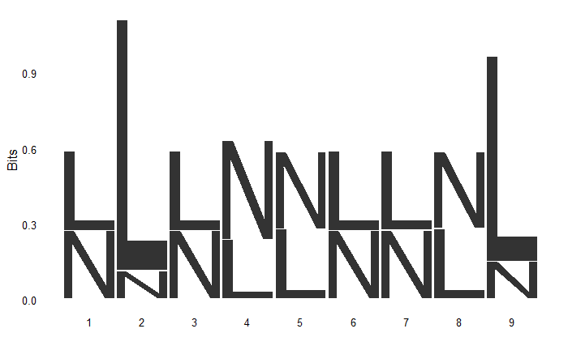

```r
# Plot a single DNA sequence logo
pepseq<- as.vector(peptidos$sequence)
ggseqlogo(pepseq,seq_type='auto', namespace = 'NULL', font='helvetica_regular', col_scheme = 'nucleotide')
```

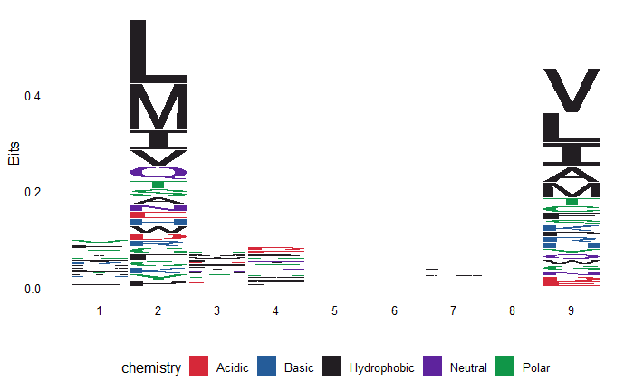

```r
ggseqlogo(peptidos$sequence, facet = "wrap")
```

## Codificación “one-hot” (one-hot encoding) de las secuencias.

**Desarrollar una función en R que implemente la codificación “one-hot” (one-hot encoding) de las secuencias.**

```r
convert <- function(l) {
 code1 <- c("10000000000000000000", "01000000000000000000", "00100000000000000000", "00010000000000000000", "00001000000000000000", "00000100000000000000", "00000010000000000000", "00000001000000000000", "00000000100000000000", "00000000010000000000", "00000000001000000000", "00000000000100000000", "00000000000010000000", "00000000000001000000", "00000000000000100000", "00000000000000010000", "00000000000000001000", "00000000000000000100", "00000000000000000010", "00000000000000000001")
 names(code1) <- c("A", "R", "N", "D", "C", "Q", "E", "G", "H", "I", "L", "K", "M", "F", "P", "S", "T", "W", "Y", "V")
     sapply(strsplit(l, "", perl = TRUE),
     function(x) paste(code1[x], collapse = ""))
}
```

## Secuencias de aminoácidos en vectores numéricos

```r
str(data.vector2[1])
```

[output not shown]

```
'data.frame':   15840 obs. of  1 variable:
 $ V1: chr  "0" "0" "0" "0" ...
```

# References

Freeman, J.A.; Skapura, DM. Redes Neuronales. Algoritmos, aplicaciones y técnicas de propagación. México: Addison-Wesley. 1993; 306 p